# Lysozyme

## Figure 4: Best-cluster predicted contact maps over the two true folds.

Predicted contact maps (MSA-Transformer) for the clusters best matching each fold, over the true contacts of fold 1 (upper triangle) and fold 2 (lower). Divergent contacts between clusters are the contact-level signature of fold-switching.

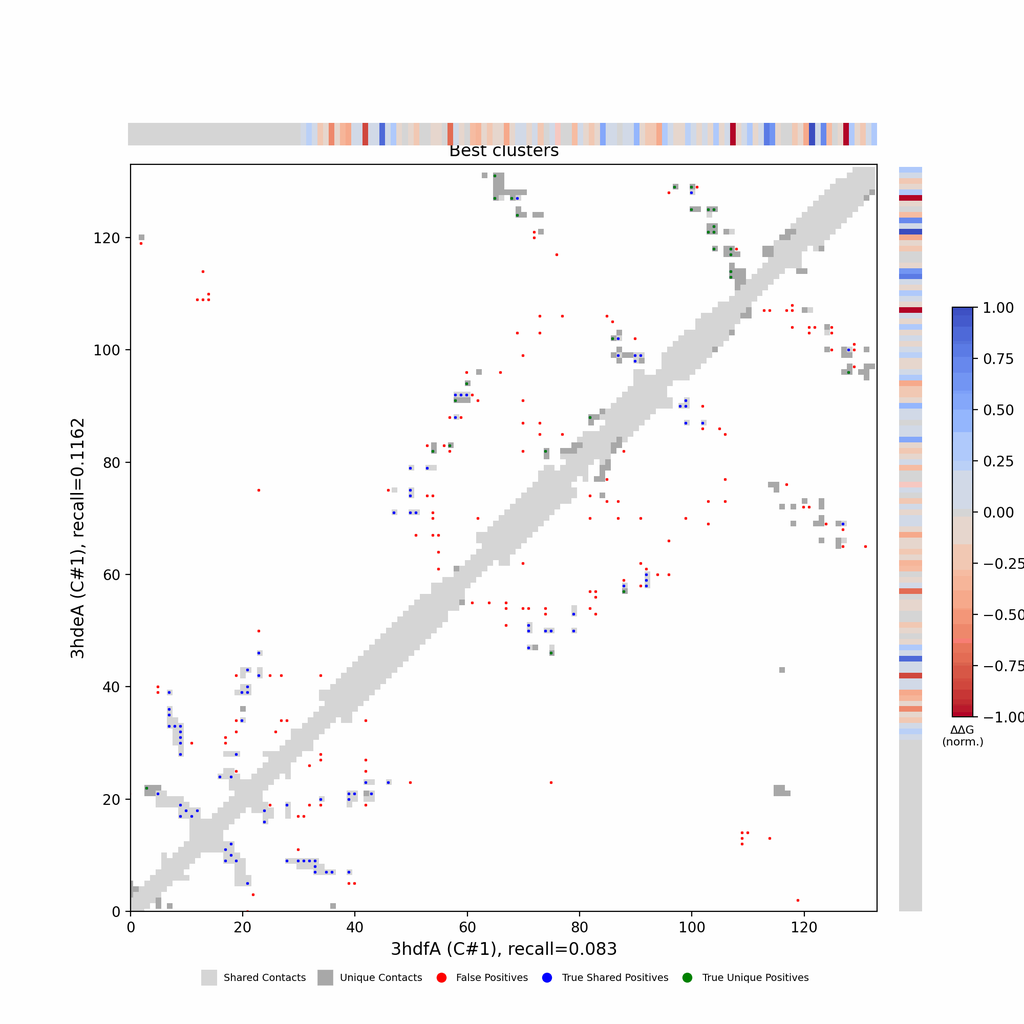

## Figure 5: Per-residue ΔΔG fold-preference contribution

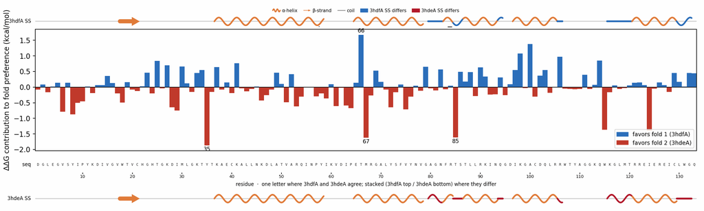

**More figures**

## Figure 6: Deep-MSA contact map panel / Best clusters contact map panel

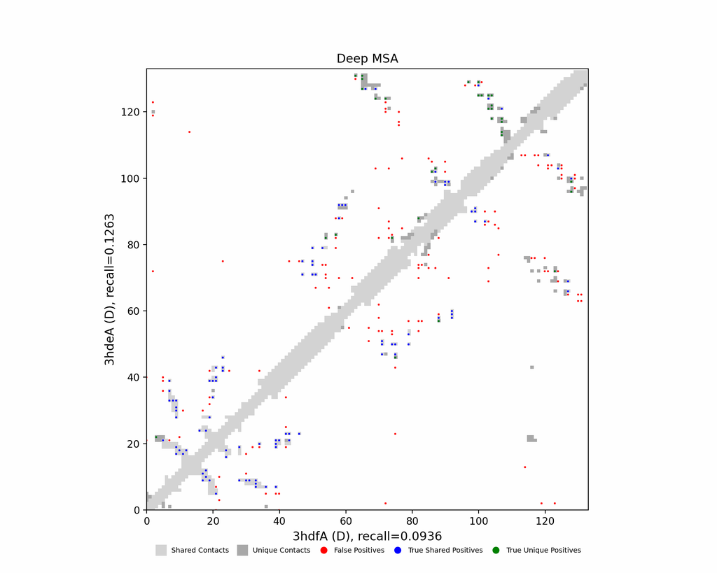

Deep-MSA contact map panel

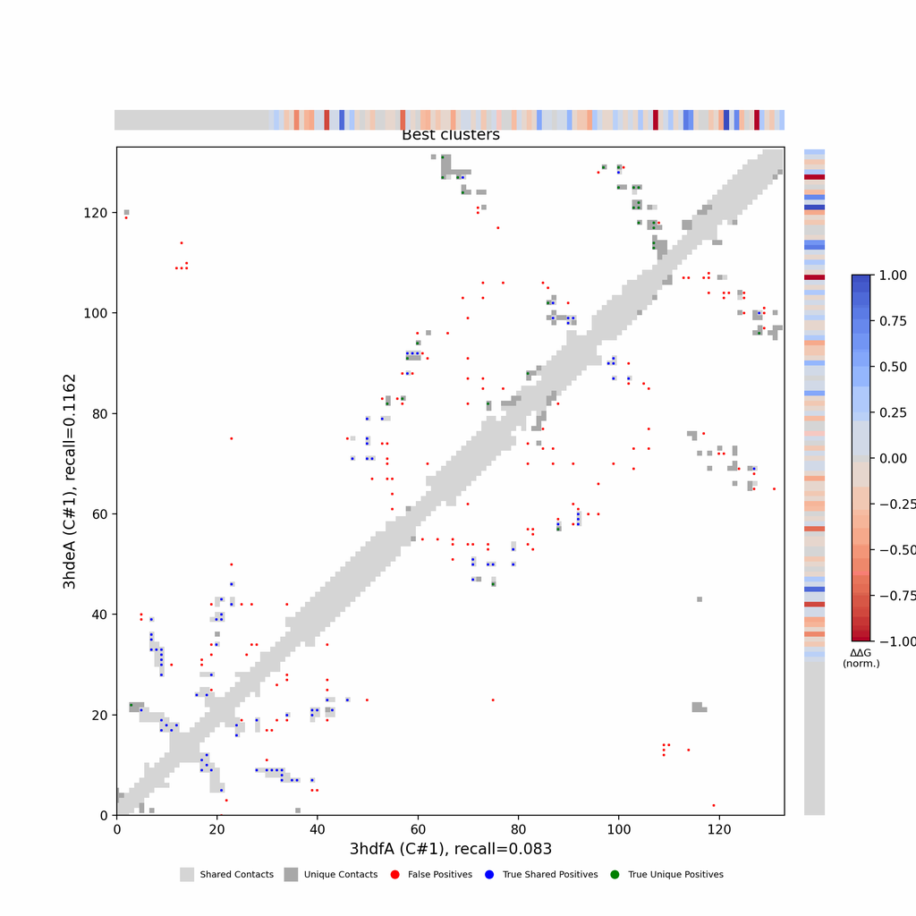

Best clusters contact map panel

## Figure 7: All clusters contact-map mosaic (small multiples).

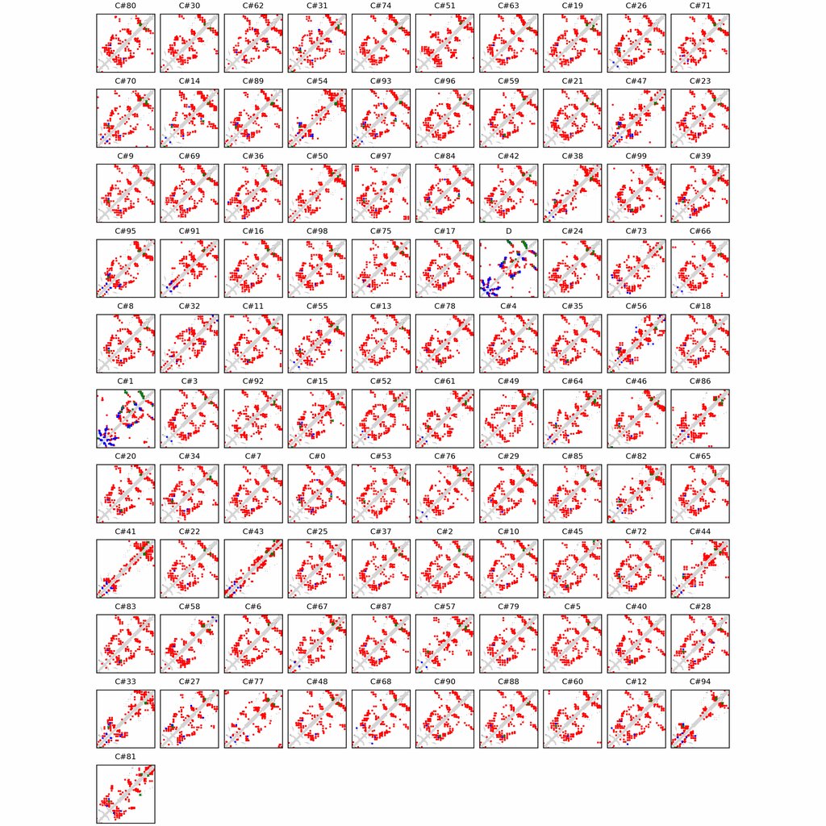

## Figure 8: Phylo null: tree with shuffled cluster fold labels.

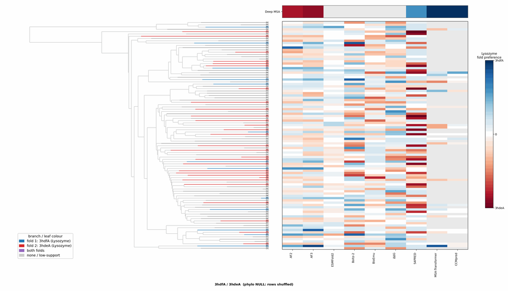

## Cluster metrics table

Per-cluster metrics underlying the figures above.

| cluster | n | neff | AF2_TM1 | AF2_TM2 | AF3_TM1 | AF3_TM2 | RE-MSAT-COM | RE-MSAT1 | RE-MSAT2 | ESM_SEQIDS | ESM_TM1 | ESM_TM2 | ΔΔG_Bias | ΔΔG_Bias_std | ΔΔG_frac_F1 | Boltz2_pref | S4PRED_pref | CCMpred_pref | BioEmu_pref |
| --- | --- | --- | --- | --- | --- | --- | --- | --- | --- | --- | --- | --- | --- | --- | --- | --- | --- | --- | --- |
| Deep | - | - | 0.8 | 0.98 | 0.8 | 0.98 | 0.42 | 0.39 | 0.44 | - | - | - | - | - | - | - | 0.06 | 0.07 | - |
| 000 | 2008.0 | 1380.0 | 0.64 | 0.62 | 0.66 | 0.67 | 0.03 | 0.05 | 0.05 | 004; 004; 007; 007; 003; 003; 006; 006; 001; 001 | 0.73 ± 0.03 | 0.79 ± 0.05 | 12.55 | 10.71 | 0.8 | 0.06 | -0.04 | 0.04 | 0.02 |
| 001 | 1062.0 | 500.0 | 0.78 | 0.62 | 0.87 | 0.67 | 0.39 | 0.37 | 0.42 | 001; 001; 003; 003; 008; 008; 005; 005; 007; 007 | 0.72 ± 0.03 | 0.78 ± 0.02 | 8.57 | 9.72 | 0.6 | 0.12 | 0.06 | 0.0 | 0.06 |
| 002 | 802.0 | 550.0 | 0.65 | 0.56 | 0.77 | 0.6 | 0.01 | 0.02 | 0.03 | 007; 007; 003; 003; 005; 005; 001; 001; 008; 006 | 0.69 ± 0.03 | 0.78 ± 0.04 | 6.13 | 7.43 | 0.7 | 0.1 | 0.06 | 0.0 | 0.03 |
| 003 | 793.0 | 574.0 | 0.63 | 0.56 | 0.64 | 0.65 | 0.02 | 0.03 | 0.04 | 002; 004; 004; 002; 007; 007; 001; 001; 003; 003 | 0.72 ± 0.02 | 0.79 ± 0.04 | 8.75 | 13.71 | 0.5 | 0.12 | -0.03 | 0.01 | 0.04 |
| 004 | 759.0 | 563.0 | 0.58 | 0.56 | 0.58 | 0.61 | 0.01 | 0.02 | 0.03 | 008; 007; 007; 008; 010; 010; 006; 006; 004; 005 | 0.71 ± 0.01 | 0.76 ± 0.07 | 7.18 | 9.47 | 0.7 | 0.11 | 0.05 | 0.01 | 0.04 |
| 005 | 538.0 | 396.0 | 0.65 | 0.6 | 0.61 | 0.57 | 0.0 | 0.01 | 0.03 | 005; 005; 001; 001; 004; 003; 004; 003; 009; 009 | 0.74 ± 0.02 | 0.77 ± 0.07 | 6.65 | 12.02 | 0.5 | 0.04 | 0.04 | 0.0 | 0.06 |
| 006 | 474.0 | 279.0 | 0.3 | 0.29 | 0.37 | 0.34 | 0.0 | 0.01 | 0.02 | 006; 006; 007; 007; 005; 008; 005; 008; 001; 001 | 0.70 ± 0.02 | 0.76 ± 0.04 | 10.07 | 12.43 | 0.8 | 0.02 | 0.06 | 0.01 | 0.03 |
| 007 | 446.0 | 309.0 | 0.38 | 0.32 | 0.35 | 0.33 | 0.01 | 0.02 | 0.03 | 004; 004; 009; 009; 005; 005; 001; 001; 008; 006 | 0.73 ± 0.02 | 0.78 ± 0.02 | 8.63 | 10.59 | 0.8 | 0.05 | 0.05 | 0.0 | 0.04 |
| 008 | 400.0 | 328.0 | 0.57 | 0.51 | 0.55 | 0.55 | 0.02 | 0.04 | 0.04 | 006; 006; 003; 003; 004; 004; 005; 005; 001; 001 | 0.73 ± 0.02 | 0.79 ± 0.05 | 4.39 | 9.57 | 0.5 | 0.02 | -0.04 | 0.01 | 0.04 |
| 009 | 380.0 | 275.0 | 0.69 | 0.61 | 0.66 | 0.68 | 0.01 | 0.02 | 0.02 | 001; 005; 005; 001; 008; 008; 009; 009; 007; 007 | 0.70 ± 0.03 | 0.75 ± 0.04 | 10.39 | 12.48 | 0.6 | 0.01 | -0.05 | 0.0 | 0.04 |
| 010 | 249.0 | 156.0 | 0.61 | 0.56 | 0.59 | 0.61 | 0.01 | 0.02 | 0.03 | 004; 004; 005; 005; 001; 003; 001; 003; 007; 007 | 0.71 ± 0.04 | 0.77 ± 0.04 | 7.49 | 9.58 | 0.8 | 0.04 | -0.03 | 0.0 | 0.03 |
| 011 | 232.0 | 171.0 | 0.62 | 0.53 | 0.65 | 0.59 | 0.01 | 0.03 | 0.01 | 008; 008; 005; 005; 006; 006; 009; 009; 001; 001 | 0.72 ± 0.03 | 0.77 ± 0.04 | 6.19 | 10.1 | 0.6 | -0.01 | 0.06 | 0.0 | 0.06 |
| 012 | 228.0 | 90.0 | 0.39 | 0.33 | 0.33 | 0.29 | 0.0 | 0.0 | 0.03 | 004; 004; 001; 005; 001; 005; 007; 007; 006; 006 | 0.71 ± 0.02 | 0.74 ± 0.07 | 11.29 | 11.0 | 0.8 | 0.04 | 0.04 | -0.0 | 0.02 |
| 013 | 228.0 | 165.0 | 0.39 | 0.35 | 0.32 | 0.34 | 0.0 | 0.01 | 0.01 | 006; 006; 001; 001; 002; 007; 009; 002; 007; 009 | 0.72 ± 0.02 | 0.74 ± 0.04 | 0.51 | 5.21 | 0.6 | 0.05 | 0.03 | -0.0 | 0.01 |
| 014 | 214.0 | 50.0 | 0.54 | 0.42 | 0.7 | 0.59 | 0.02 | 0.04 | 0.04 | 007; 007; 006; 006; 001; 001; 008; 009; 008; 009 | 0.70 ± 0.03 | 0.73 ± 0.05 | 7.74 | 9.0 | 0.7 | 0.14 | 0.06 | 0.0 | 0.04 |
| 015 | 206.0 | 115.0 | 0.51 | 0.48 | 0.57 | 0.56 | 0.03 | 0.06 | 0.04 | 008; 008; 003; 001; 001; 003; 005; 005; 004; 004 | 0.71 ± 0.01 | 0.75 ± 0.04 | 1.76 | 9.24 | 0.5 | 0.06 | 0.06 | -0.0 | 0.04 |
| 016 | 201.0 | 101.0 | 0.57 | 0.52 | 0.64 | 0.64 | 0.01 | 0.02 | 0.03 | 005; 005; 006; 006; 009; 009; 001; 001; 008; 007 | 0.70 ± 0.04 | 0.76 ± 0.04 | 11.79 | 10.3 | 0.8 | 0.07 | 0.05 | 0.0 | 0.05 |
| 017 | 193.0 | 142.0 | 0.56 | 0.52 | 0.38 | 0.35 | 0.01 | 0.02 | 0.03 | 007; 007; 001; 006; 006; 001; 005; 008; 009; 005 | 0.72 ± 0.01 | 0.77 ± 0.03 | 13.11 | 12.32 | 0.7 | 0.03 | 0.01 | 0.0 | 0.05 |
| 018 | 192.0 | 139.0 | 0.7 | 0.64 | 0.61 | 0.62 | 0.01 | 0.02 | 0.04 | 004; 004; 001; 006; 006; 001; 005; 005; 007; 007 | 0.72 ± 0.02 | 0.76 ± 0.04 | 6.57 | 9.94 | 0.6 | -0.02 | 0.05 | 0.0 | 0.04 |
| 019 | 189.0 | 112.0 | 0.6 | 0.61 | 0.59 | 0.62 | 0.01 | 0.03 | 0.03 | 005; 005; 009; 009; 008; 006; 006; 008; 010; 010 | 0.73 ± 0.01 | 0.76 ± 0.01 | 8.76 | 9.54 | 0.7 | -0.01 | 0.04 | 0.0 | 0.01 |
| 020 | 188.0 | 97.0 | 0.52 | 0.46 | 0.5 | 0.52 | 0.01 | 0.02 | 0.02 | 005; 007; 005; 007; 006; 006; 001; 001; 002; 002 | 0.73 ± 0.02 | 0.75 ± 0.04 | 2.54 | 9.16 | 0.5 | 0.01 | -0.02 | 0.0 | 0.04 |
| 021 | 170.0 | 130.0 | 0.55 | 0.48 | 0.54 | 0.51 | 0.01 | 0.02 | 0.03 | - | - | - | 3.2 | 8.29 | 0.6 | 0.07 | -0.05 | - | 0.02 |
| 022 | 166.0 | 101.0 | 0.59 | 0.58 | 0.54 | 0.5 | 0.01 | 0.02 | 0.03 | - | - | - | 4.43 | 9.0 | 0.6 | 0.09 | 0.05 | - | 0.04 |
| 023 | 164.0 | 100.0 | 0.43 | 0.38 | 0.72 | 0.64 | 0.01 | 0.02 | 0.03 | - | - | - | 7.71 | 14.85 | 0.6 | 0.01 | -0.02 | - | 0.03 |
| 024 | 161.0 | 56.0 | 0.35 | 0.28 | 0.29 | 0.26 | 0.02 | 0.03 | 0.01 | - | - | - | 10.54 | 9.53 | 0.8 | 0.02 | -0.05 | - | 0.02 |
| 025 | 157.0 | 90.0 | 0.44 | 0.38 | 0.35 | 0.29 | 0.01 | 0.01 | 0.02 | - | - | - | 0.6 | 3.17 | 0.6 | 0.04 | 0.06 | - | 0.03 |
| 026 | 156.0 | 104.0 | 0.63 | 0.63 | 0.57 | 0.6 | 0.02 | 0.03 | 0.04 | - | - | - | 3.97 | 6.44 | 0.8 | 0.07 | -0.05 | - | 0.04 |
| 027 | 153.0 | 56.0 | 0.63 | 0.54 | 0.49 | 0.54 | 0.03 | 0.03 | 0.04 | - | - | - | 5.87 | 8.64 | 0.6 | 0.1 | -0.02 | - | 0.03 |
| 028 | 148.0 | 85.0 | 0.54 | 0.48 | 0.64 | 0.67 | 0.02 | 0.04 | 0.03 | - | - | - | 6.96 | 10.45 | 0.7 | 0.06 | 0.01 | - | 0.05 |

[output cut: 71 more lines]